# 310657002_林奕勳_統計碩_final_exam

# c

from b model , we just see coefficients of Posnodes

```r
Q2_c_model<-glm(cbind(EVENTmeta_y, EVENTmeta_n)~Posnodes+SBPgrp1+SBPgrp3+Posnodes:SBPgrp1+Posnodes:SBPgrp3, family=binomial, data=Q2_b_table)
summary(Q2_c_model)
```

```
##
## Call:
## glm(formula = cbind(EVENTmeta_y, EVENTmeta_n) ~ Posnodes + SBPgrp1 +
##     SBPgrp3 + Posnodes:SBPgrp1 + Posnodes:SBPgrp3, family = binomial,
##     data = Q2_b_table)
##
## Deviance Residuals:
## [1]  0  0  0  0  0  0
##
## Coefficients:
##                  Estimate Std. Error z value Pr(>|z|)
## (Intercept)      -0.99040    0.32480  -3.049  0.00229 **
## Posnodes          0.16720    0.43063   0.388  0.69782
## SBPgrp1           0.71081    0.40267   1.765  0.07752 .
## SBPgrp3           0.24846    0.50310   0.494  0.62141
## Posnodes:SBPgrp1 -0.53820    0.60737  -0.886  0.37556
## Posnodes:SBPgrp3 -0.08856    0.64976  -0.136  0.89159
## ---
## Signif. codes:  0 '***' 0.001 '**' 0.01 '*' 0.05 '.' 0.1 ' ' 1
##
## (Dispersion parameter for binomial family taken to be 1)
##
##     Null deviance:  3.9640e+00  on 5  degrees of freedom
## Residual deviance: -1.8208e-14  on 0  degrees of freedom
## AIC: 37.148
##
## Number of Fisher Scoring iterations: 3
```

```r
low =exp( 0.24846  - 1.96*0.50310     )
up = exp(0.24846 + 1.96*0.50310    )
cat('the 95% confidence interval of the odds ratio ',c(low,up))
```

```
## the 95% confidence interval of the odds ratio  0.4782527 3.436783
```

I use medium expression be a baseline and fit logistic regression model , so we just see coefficient of SBPgrp3 . # d

```r
Q2_d_model<-glm(cbind(EVENTmeta_y, EVENTmeta_n)~Posnodes+SBPgrp2+SBPgrp3, family=binomial, data=Q2_b_table)
summary(Q2_d_model)
```

```
##
## Call:
## glm(formula = cbind(EVENTmeta_y, EVENTmeta_n) ~ Posnodes + SBPgrp2 +
##     SBPgrp3, family = binomial, data = Q2_b_table)
##
## Deviance Residuals:
##       1        2        3        4        5        6
##  0.4215  -0.3826  -0.2140  -0.6149   0.3437   0.1688
##
## Coefficients:
##             Estimate Std. Error z value Pr(>|z|)
## (Intercept) -0.38017    0.21389  -1.777   0.0755 .
## Posnodes    -0.05373    0.25511  -0.211   0.8332
## SBPgrp2     -0.48710    0.29579  -1.647   0.0996 .
## SBPgrp3     -0.27992    0.31601  -0.886   0.3757
## ---
## Signif. codes:  0 '***' 0.001 '**' 0.01 '*' 0.05 '.' 0.1 ' ' 1
##
## (Dispersion parameter for binomial family taken to be 1)
##
##     Null deviance: 3.96399  on 5  degrees of freedom
## Residual deviance: 0.89459  on 2  degrees of freedom
## AIC: 34.043
##
## Number of Fisher Scoring iterations: 3
```

```r
1-pchisq(Q2_d_model$deviance-Q2_b_model$deviance, df=2)
```

```
## [1] 0.6393541
```

# e

```r
Q2_e_model_1<-glm(cbind(EVENTmeta_y, EVENTmeta_n)~SBPgrp2+SBPgrp3, family=binomial, data=Q2_b_table)
summary(Q2_e_model_1)
```

```
##
## Call:
## glm(formula = cbind(EVENTmeta_y, EVENTmeta_n) ~ SBPgrp2 + SBPgrp3,
##     family = binomial, data = Q2_b_table)
##
## Deviance Residuals:
##        1         2         3         4         5         6
##  0.49470  -0.29037  -0.12735  -0.71883   0.25885   0.09984
##
## Coefficients:
##             Estimate Std. Error z value Pr(>|z|)
## (Intercept)  -0.3977     0.1972  -2.017   0.0437 *
## SBPgrp2      -0.4991     0.2903  -1.719   0.0856 .
## SBPgrp3      -0.2955     0.3073  -0.961   0.3363
## ---
## Signif. codes:  0 '***' 0.001 '**' 0.01 '*' 0.05 '.' 0.1 ' ' 1
##
## (Dispersion parameter for binomial family taken to be 1)
##
##     Null deviance: 3.96399  on 5  degrees of freedom
## Residual deviance: 0.93896  on 3  degrees of freedom
## AIC: 32.087
##
## Number of Fisher Scoring iterations: 3
```

```r
1-pchisq(Q2_e_model_1$deviance-Q2_d_model$deviance, df=1)
```

```
## [1] 0.8331803
```

```r
intercept_model<-glm(cbind(EVENTmeta_y, EVENTmeta_n)~1, family=binomial, data=Q2_b_table)
summary(intercept_model)
```

```
##
## Call:
## glm(formula = cbind(EVENTmeta_y, EVENTmeta_n) ~ 1, family = binomial,
##     data = Q2_b_table)
##
## Deviance Residuals:
##        1         2         3         4         5         6
##  1.55010  -1.06498  -0.23336   0.00604  -0.60931  -0.03538
##
## Coefficients:
##             Estimate Std. Error z value Pr(>|z|)
## (Intercept)  -0.6527     0.1227   -5.32 1.04e-07 ***
## ---
## Signif. codes:  0 '***' 0.001 '**' 0.01 '*' 0.05 '.' 0.1 ' ' 1
##
## (Dispersion parameter for binomial family taken to be 1)
##
##     Null deviance: 3.964  on 5  degrees of freedom
## Residual deviance: 3.964  on 5  degrees of freedom
## AIC: 31.112
##
## Number of Fisher Scoring iterations: 3
```

Use goodness-of-fit find that the intercept_model fit well , and the intercept term is significant

# Q3

# a

```r
Prognosis  = rep(0,dim(data)[1])
Prognosis [data$conservFlag == 0 & data$C1used > 0.4 ] = 1
Prognosis [data$conservFlag != 0 & data$C1used > 0.55 ] = 1
Q3_table = table(Prognosis )
names(Q3_table)= c('poor','good')
Q3_table
```

```
## poor good
##  180  115
```

# b

we can use chi-square test

```r
table(Prognosis ,data$EVENTmeta)
```

```
##
## Prognosis  0  1
##         0 95 85
##         1 99 16
```

```r
chisq.test(table(Prognosis ,data$EVENTmeta))
```

```
##
##  Pearson's Chi-squared test with Yates' continuity correction
##
## data:  table(Prognosis, data$EVENTmeta)
## X-squared = 33.114, df = 1, p-value = 8.69e-09
```

```r
Q3_b_model = glm(data$EVENTmeta~Prognosis , family=binomial)
Q3_b_model_base = glm(data$EVENTmeta~1 , family=binomial)
summary(Q3_b_model)
```

```
##
## Call:
## glm(formula = data$EVENTmeta ~ Prognosis, family = binomial)
##
## Deviance Residuals:
##     Min       1Q   Median       3Q      Max
## -1.1306  -1.1306  -0.5474   1.2250   1.9861
##
## Coefficients:
##             Estimate Std. Error z value Pr(>|z|)
## (Intercept)  -0.1112     0.1493  -0.745    0.456
## Prognosis    -1.7113     0.3080  -5.555 2.77e-08 ***
## ---
## Signif. codes:  0 '***' 0.001 '**' 0.01 '*' 0.05 '.' 0.1 ' ' 1
##
## (Dispersion parameter for binomial family taken to be 1)
##
##     Null deviance: 379.13  on 294  degrees of freedom
## Residual deviance: 341.75  on 293  degrees of freedom
## AIC: 345.75
##
## Number of Fisher Scoring iterations: 4
```

from chi-square test show that p-value < 0.05 , reject $H_0$(i.e then are dependent) , and we can use logistic regression predict .

# c

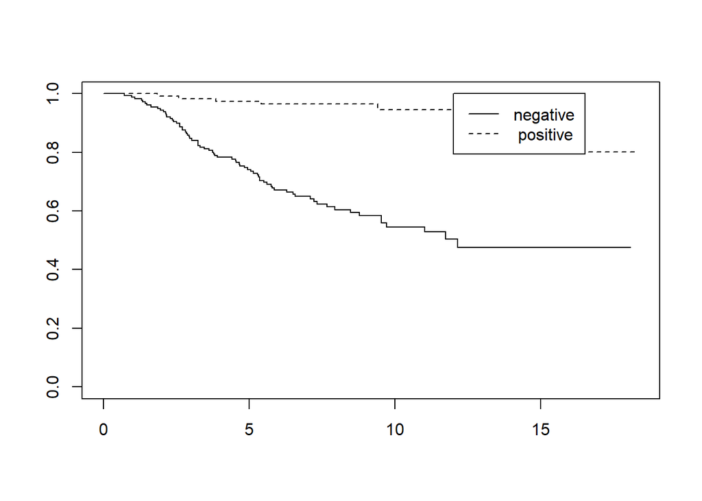

```r
survival_c = survfit(Surv(TIMEsurvival, EVENTdeath)~Prognosis , data=data,  type=c("kaplan-meier"))
plot(survival_c,lty=1:2)
legend(12, 1, c("negative", " positive "),lty=1:2)
```

```r
survdiff(Surv(TIMEsurvival, EVENTdeath)~Prognosis , data=data)
```

```
## Call:
## survdiff(formula = Surv(TIMEsurvival, EVENTdeath) ~ Prognosis,
##     data = data)
##
##               N Observed Expected (O-E)^2/E (O-E)^2/V
## Prognosis=0 180       72     43.1      19.3      42.8
## Prognosis=1 115        7     35.9      23.2      42.8
##
##  Chisq= 42.8  on 1 degrees of freedom, p= 6e-11
```

# d

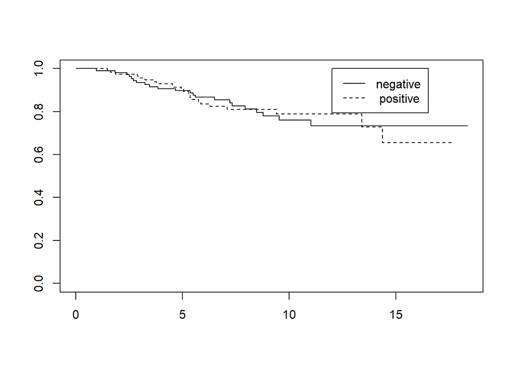

```r
data_ESR1 = data[data$ESR1==1,]
data_ESR0 = data[data$ESR1==0,]

survival_e_ESR1 = survfit(Surv(TIMEsurvival, EVENTdeath)~Posnodes , data=data_ESR1,  type=c("kaplan-meier"))
plot(survival_e_ESR1,lty=1:2)
legend(12, 1, c("negative", " positive "),lty=1:2)
```

```r
survdiff(Surv(TIMEsurvival, EVENTdeath)~Posnodes , data=data_ESR1)
```

```
## Call:
## survdiff(formula = Surv(TIMEsurvival, EVENTdeath) ~ Posnodes,
##     data = data_ESR1)
##
##              N Observed Expected (O-E)^2/E (O-E)^2/V
## Posnodes=n 109       22     22.1  0.000754   0.00148
## Posnodes=y 117       23     22.9  0.000729   0.00148
##
##  Chisq= 0  on 1 degrees of freedom, p= 1
```

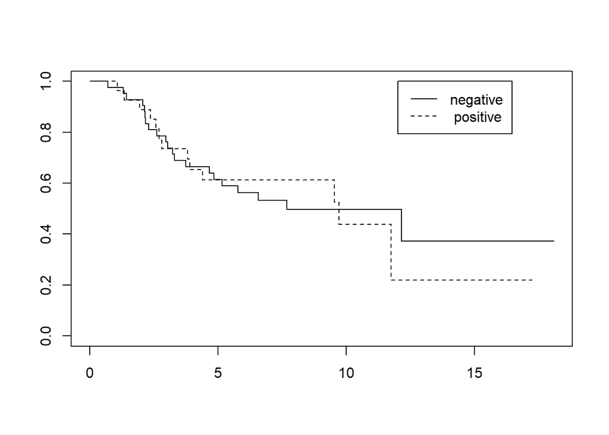

```r
survival_e_ESR0 = survfit(Surv(TIMEsurvival, EVENTdeath)~Posnodes , data=data_ESR0,  type=c("kaplan-meier"))
plot(survival_e_ESR0,lty=1:2)
legend(12, 1, c("negative", " positive "),lty=1:2)
```

```r
survdiff(Surv(TIMEsurvival, EVENTdeath)~Posnodes , data=data_ESR0)
```

```
## Call:
## survdiff(formula = Surv(TIMEsurvival, EVENTdeath) ~ Posnodes,
##     data = data_ESR0)
##
##             N Observed Expected (O-E)^2/E (O-E)^2/V
## Posnodes=n 42       21     20.9  0.000128  0.000336
## Posnodes=y 27       13     13.1  0.000206  0.000336
##
##  Chisq= 0  on 1 degrees of freedom, p= 1
```

I group by ESR1 , and respectively plot two survival curves